# IE - Master in Business Analytics and Big Data

Recommendation Systems

Building a Collaborative Filtering Engine

Author: Annie Pi / Last Updated: Feb. 13, 2018

========================================================

# Initialization

Import libraries

```r
library(dplyr) #for chained manipulations and calculations
library(ggplot2) #for data visualization
library(gridExtra) #for arranging graphs in a grid
```

Load the critics dataset.

```r
critics <- read.csv("critics.csv")
```

# 1) Pearson correlation coefficient

Calculate the Pearson correlation coefficient between Victoria and Nuria

**Expected correlation between Victoria and Nuria**: 0.3651484

```r
#transpose critics and set reviewer names as column titles
critics_T = setNames(data.frame(t(critics[,-1])), critics[,1])

#calculate pearson correlation between Nuria and Victoria using transposed dataframe
cor(critics_T$Nuria, critics_T$Victoria, use='complete.obs')
```

```
## [1] 0.3651484
```

# 2) Compare two movie critics

Using the calculated Pearson correlation in the previous section. Compare and show the movie ratings for Victoria and Nuria on a scatter plot. How is this compared with the same ratings of Maria and Nerea on a scatter plot? What about Chris and Jim? What it means?

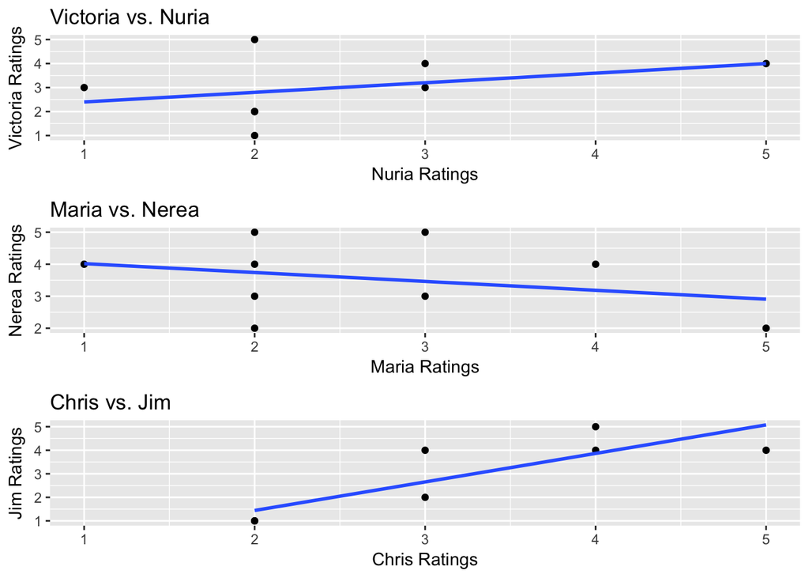

```r
#create scatter plot comparing Victoria and Nuria
chart1 = critics_T %>%
  ggplot(aes(x=Nuria, y=Victoria)) +
  geom_point() +
  geom_smooth(method="lm", se=F) +
  labs(x="Nuria Ratings", y="Victoria Ratings", title="Victoria vs. Nuria")

#create scatter plot comparing Maria and Nerea
chart2 = critics_T %>%
  ggplot(aes(x=Maria, y=Nerea)) +
  geom_point() +
    geom_smooth(method="lm", se=F) +
  labs(x="Maria Ratings", y="Nerea Ratings", title="Maria vs. Nerea")

#create scatter plot comparing Chris and Jim
chart3 = critics_T %>%
  ggplot(aes(x=Chris, y=Jim)) +
  geom_point() +
  geom_smooth(method="lm", se=F) +
  labs(x="Chris Ratings", y="Jim Ratings", title="Chris vs. Jim")

#show three scatter plots
grid.arrange(chart1, chart2, chart3, nrow=3)
```

There appears to be a slight positive correlation between Nuria and Victoria’s ratings. As Nuria’s movie ratings increase, some of Victoria’s ratings also increase, suggesting they have somewhat similar tastes. However, not all movies follow this pattern: for example, a movie that Nuria rated as only a 2, Victoria rated as a 5.

On the other hand, there is a negative correlation between Nerea and Maria’s ratings. Movies that Nerea likes, Maria tends to dislike, and vice versa. Again, there are some discrepancies, but this general trend is followed.

There is also a positive relationship between Chris and Jim. They both tend to rate movies similarly and positively (most fall at the higher end of the scale).

# 3) Top Recommendations

Get the top 5 movies recommended for Victoria. by using a weighted average of every other critic’s rankings.

**Expected result**: ‘The Matrix’ ‘Forrest Gump’  
‘The Sixth Sense’ ‘Shakespeare in Love’ ‘Blade Runner’

```r
#create an empty data frame to store weighted averages (Pearson correlations)
weightedAvg <- data.frame()

#loop through all critics, calculate correlation of each critic's ratings with Victoria, and append to WeightedAvg
for(i in 1:ncol(critics_T)) {
    corr = cor(critics_T$Victoria, critics_T[,i], use='complete.obs')
    weightedAvg = rbind(weightedAvg, data.frame(weights = corr))
}

#calculate absolute sum of weighted averages
weightedSum = sum(abs(weightedAvg))

#calculate Victoria's average rating
victoriaAvg = mean(critics_T$Victoria, na.rm = T)

#create an empty data frame to store critic averages
criticAvgs <- data.frame()

#calculate average rating for each critic
for (c in 1:ncol(critics_T)) {
    criticAvg = mean(critics_T[,c], na.rm = T)
    criticAvgs = rbind(criticAvgs, data.frame(criticAvg = criticAvg))
    #scaledRatings = cbind(scaledRatings, critnames[c])
    }

#scale all ratings using average critic ratings
for(c in 1:ncol(critics_T)) {
  for (r in 1:nrow(critics_T)) {
    if(is.na(critics_T[r,c]) == FALSE) {
      critics_T[r,c] = critics_T[r,c] - criticAvgs[c,]
    }
  }
}

#multiply scaled ratings by personalized user weight
for(c in 1:ncol(critics_T)) {
  for (r in 1:nrow(critics_T)) {
    if(is.na(critics_T[r,c]) == FALSE) {
      critics_T[r,c] = critics_T[r,c] * weightedAvg[c,]
    }
  }
}

#create a df that applies weighted average formula to calculate a score for each movie
df <- data.frame(victoriaAvg + rowSums(critics_T, na.rm = T)/weightedSum)

#set column names for df
df2 = setNames(cbind(colnames(critics[2:21]), df, row.names = NULL),
  c("MovieName", "Score"))

#select only Victoria's ratings
vic = critics_T %>%
  select(Victoria)

#set column names for vic
vic2 = setNames(cbind(colnames(critics[2:21]), vic, row.names = NULL),
  c("MovieName", "Victoria"))

#filter for only movies Victoria has watched
vic2 = vic2 %>%
  filter(!is.na(Victoria))

#filter results for movies that Victoria has not watched and arrange descending based on score
df2 %>%
  filter(!MovieName %in% vic2$MovieName) %>%
  arrange(desc(Score)) %>%
  select(MovieName) %>%
  head(5)
```

```
##             MovieName
## 1          The.Matrix
## 2        Forrest.Gump
## 3     The.Sixth.Sense
## 4 Shakespeare.in.Love
## 5        Blade.Runner
```

# 4) Top similar critics

Return the top 5 critics that are most similar to Victoria.

**Expected result**: 0.9449112, ‘Rachel’ 0.5976143, ‘Ana’ 0.5789794, ‘Oriol’ 0.4925922, ‘Maria’ 0.4273247, ‘Carles’

```r
#add critic names to Pearson correlation scores
weightedAvg2 = setNames(cbind(critics$User, weightedAvg, row.names = NULL),
  c("CriticName", "Pearson"))

#remove Victoria, arrange descending by Pearson correlation, and select top 5
weightedAvg2 %>%
  dplyr::filter(CriticName != "Victoria") %>%
  arrange(desc(Pearson)) %>%
  select(Pearson, CriticName) %>%
  head(5)
```

```
##     Pearson CriticName
## 1 0.9449112     Rachel
## 2 0.5976143        Ana
## 3 0.5789794      Oriol
## 4 0.4925922      Maria
## 5 0.4273247     Carles
```